# Lab 7 Assignment: Group 03

### Group members:

s225049: Ida Sofie Goldschmidt  
s225074: Annekatrine Kirketerp-Møller  
s225051: Emil August Dissing Berntsen  
s224974: Rasmus Kamp  
s215109: Rolf Larsen

## Load libraries

```r
suppressWarnings(suppressPackageStartupMessages({
  library("tidyverse")
  library("broom")
  library("cowplot")
  library("ggrepel")
}))
```

## Loading and tidying data:

```r
biopsy <- read_csv("https://wilkelab.org/classes/SDS348/data_sets/biopsy.csv")
```

To do the PCA, we first need to remove all non-numeric columns, since the function *prcomp* does not take non-numeric inputs. The PCA is then stored in the function *pca_fit*. We also need to scale the data, to make sure that the difference in value ranges does not interfere with the analysis.

```r
pca_fit <- biopsy |>
  select(where(is.numeric)) |>
  prcomp(scale = TRUE)
```

## Data in PC coordinates

To see how well the first two PCA components divide the data into malignant and benign, the original data is fitted onto these components and plotted.

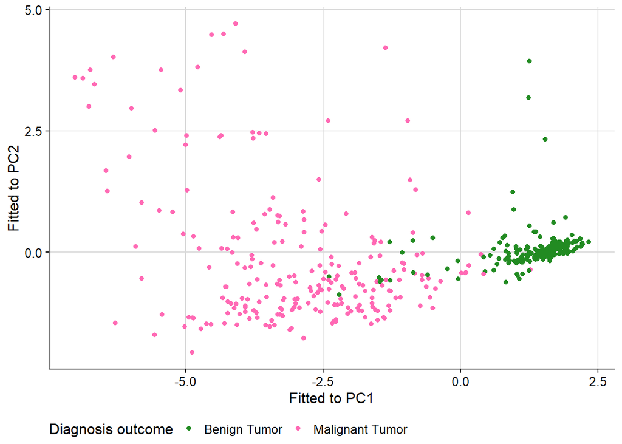

```r
pca_fit |>
  augment(biopsy) |>
  ggplot(aes(.fittedPC1, .fittedPC2,
             color = outcome)) +
  geom_point(size = 1.5) +
  scale_color_manual(
    values = c(malignant = "hotpink",
               benign = "forestgreen"),
    labels = c(malignant = "Malignant Tumor",
               benign = "Benign Tumor")) +
  theme_half_open(12) + background_grid() +
  labs(x = "Fitted to PC1",
       y = "Fitted to PC2",
       color = "Diagnosis outcome") +
  theme(legend.position = "bottom")
```

The data seems to be nicely seperated into benign and malignant by the first two principal components.

## Rotation matrix

To plot the rotation matrix for the PC1 and PC2, we subtract the rotation matrix from *pca_fit*, and plot each of the variables from the rotation matrix against PC1 and PC2.

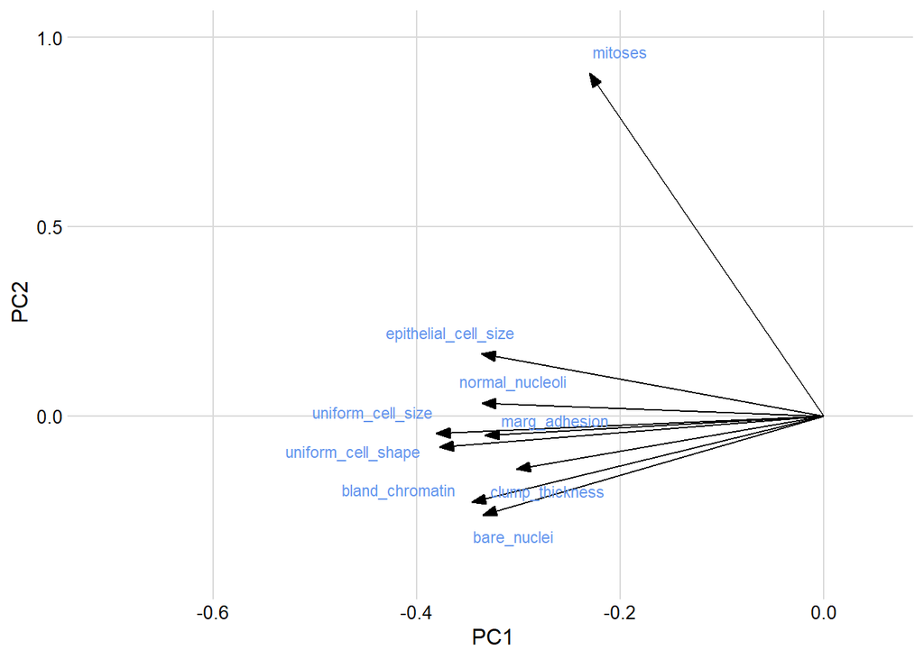

```r
# define arrow style for plotting
arrow_style <- arrow(
                angle = 20,
                ends = "first",
                type = "closed",
                length = grid::unit(8, "pt"))

# plot rotation matrix
pca_fit |>
  tidy(matrix = "rotation") |>
  pivot_wider(names_from = "PC",
              names_prefix = "PC",
              values_from = "value") |>
  ggplot(aes(PC1, PC2)) +
  geom_segment(xend = 0,
               yend = 0,
               arrow = arrow_style) +
  geom_text_repel(
    aes(label = column),
    point.padding = unit(0.5, "lines"),
    box.padding = unit(0.5, "lines"),
    segment.size =0.2,
    color = "cornflowerblue", size = 3) +

  xlim(-.7, .05) +
  ylim(-.4, 1) +
  theme_minimal_grid(12)
```

It is seen on the plot, that the variables all have a negative PC1 value and most have a neutral PC2 value, except for “Mitoses” which has a positive PC2.

## Variance explained by each PC

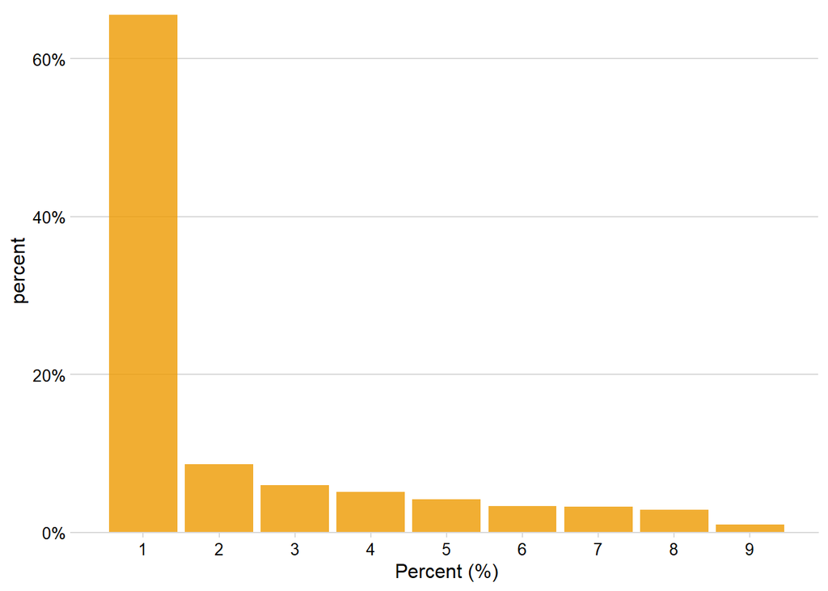

```r
pca_fit |>
  tidy(matrix = "eigenvalues") |>
  ggplot(aes(PC, percent)) +
  geom_col(fill = "orange2",
           alpha = 0.8) +
  scale_x_continuous(breaks = 1:9) +
  scale_y_continuous(
    labels = scales::percent_format(),
    expand = expansion(mult = c(0, 0.01))
  ) +
  theme_minimal_hgrid(12) +
  labs(x = "Percent (%)")
```

It is seen that 65% of the variance is explained by PC1.